# Vivacity Active Travel Sensor Analysis Cleaned

Nanxi Lu

2026-05-28

## 1 Purpose

This notebook takes the cleaned daily Vivacity sensor files as its starting point and prepares them for the main analysis stage.

The core tasks are: identifying the first date on which each sensor produced reliable data; distinguishing structural periods of sensor absence from genuine zero active travel flows; and producing sensor-level and scheme-level weekly and monthly count summaries.

The output is a set of analysis-ready tables and initial descriptive plots. At this stage the work is diagnostic — the central question is whether each sensor has sufficient pre-installation data to support a before/after comparison, or whether only a post-installation trajectory can be described.

## 2 Packages and Paths

```r
packages <- c(
  "tidyverse",
  "lubridate",
  "janitor",
  "scales",
  "fs",
  "slider"
)

missing_packages <- packages[!packages %in% rownames(installed.packages())]
if (length(missing_packages) > 0) {
  install.packages(missing_packages)
}

library(tidyverse)
library(lubridate)
library(janitor)
library(scales)
library(fs)
```

```r
clean_dir <- "/Users/lu_nanxi/CASA/Dissertation_Data/Vivacity_data_cleaned"
qa_dir <- file.path(clean_dir, "quality_checks")
output_dir <- "/Users/lu_nanxi/CASA/Dissertation_Data/Vivacity_R_outputs"

dir_create(output_dir)
dir_create(file.path(output_dir, "plots"))
dir_create(file.path(output_dir, "tables"))
```

## 3 Load Cleaned Daily Sensor Files

```r
sensor_files <- dir_ls(
  clean_dir,
  recurse = TRUE,
  regexp = "_daily\\.csv$"
) |>
  as.character() |>
  keep(~ !str_detect(basename(.x), "_all_countlines_daily\\.csv$"))

sensor_files
```

```
##  [1] "/Users/lu_nanxi/CASA/Dissertation_Data/Vivacity_data_cleaned/12b_Cronton_Road_S96_S97/46676_s96_CrontonRd_road_mt001_daily.csv"
##  [2] "/Users/lu_nanxi/CASA/Dissertation_Data/Vivacity_data_cleaned/12b_Cronton_Road_S96_S97/46686_s97_CrontonRd_road_mt001_daily.csv"
##  [3] "/Users/lu_nanxi/CASA/Dissertation_Data/Vivacity_data_cleaned/12b_Cronton_Road_S96_S97/46687_s97_CrontonRd_path_LHS_mt001_daily.csv"
##  [4] "/Users/lu_nanxi/CASA/Dissertation_Data/Vivacity_data_cleaned/12b_Cronton_Road_S96_S97/46688_s96_CrontonRd_path_RHS_mt001_daily.csv"
##  [5] "/Users/lu_nanxi/CASA/Dissertation_Data/Vivacity_data_cleaned/12d_Aigburth_Road_S17_S45/16373_S17_AigburthRd_road_east_mt001_daily.csv"
##  [6] "/Users/lu_nanxi/CASA/Dissertation_Data/Vivacity_data_cleaned/12d_Aigburth_Road_S17_S45/16374_S17_AigburthRd_path_LHS_mt001_daily.csv"
##  [7] "/Users/lu_nanxi/CASA/Dissertation_Data/Vivacity_data_cleaned/12d_Aigburth_Road_S17_S45/16393_S17_AigburthRd_west_mt001_daily.csv"
##  [8] "/Users/lu_nanxi/CASA/Dissertation_Data/Vivacity_data_cleaned/12d_Aigburth_Road_S17_S45/16394_S17_AigburthRd_path_RHS_mt001_daily.csv"
##  [9] "/Users/lu_nanxi/CASA/Dissertation_Data/Vivacity_data_cleaned/12d_Aigburth_Road_S17_S45/23779_s45_AigburthRoad_mt001_daily.csv"
## [10] "/Users/lu_nanxi/CASA/Dissertation_Data/Vivacity_data_cleaned/12e_Park_Road_S175_S177/51794_S175_ParkRd_road_mt001_daily.csv"
## [11] "/Users/lu_nanxi/CASA/Dissertation_Data/Vivacity_data_cleaned/12e_Park_Road_S175_S177/51795_S175_ParkRd_path_LHS_mt001_daily.csv"
## [12] "/Users/lu_nanxi/CASA/Dissertation_Data/Vivacity_data_cleaned/12e_Park_Road_S175_S177/51796_S175_ParkRd_path_RHS_mt001_daily.csv"
## [13] "/Users/lu_nanxi/CASA/Dissertation_Data/Vivacity_data_cleaned/12e_Park_Road_S175_S177/51817_S177_PathOffParkRd_path_mt001_daily.csv"
## [14] "/Users/lu_nanxi/CASA/Dissertation_Data/Vivacity_data_cleaned/12e_Park_Road_S175_S177/51818_S177_PathOffParkRd_path_RHS_mt001_daily.csv"
## [15] "/Users/lu_nanxi/CASA/Dissertation_Data/Vivacity_data_cleaned/12f_Leasowe_Road_S51/23799_s51_LeasoweRoad_LHS_path_mt001_daily.csv"
## [16] "/Users/lu_nanxi/CASA/Dissertation_Data/Vivacity_data_cleaned/12f_Leasowe_Road_S51/23800_s51_LeasoweRoad_road_mt001_daily.csv"
## [17] "/Users/lu_nanxi/CASA/Dissertation_Data/Vivacity_data_cleaned/12f_Leasowe_Road_S51/23801_s51_LeasoweRoad_RHS_path_mt001_daily.csv"
## [18] "/Users/lu_nanxi/CASA/Dissertation_Data/Vivacity_data_cleaned/13_Astmoor_Warrington_Road_S102_S103/47768_S102_AstmoorBusway_road_mt001_daily.csv"
## [19] "/Users/lu_nanxi/CASA/Dissertation_Data/Vivacity_data_cleaned/13_Astmoor_Warrington_Road_S102_S103/47769_S102_AstmoorBusway_path_RHS_mt001_daily.csv"
## [20] "/Users/lu_nanxi/CASA/Dissertation_Data/Vivacity_data_cleaned/13_Astmoor_Warrington_Road_S102_S103/47772_S103_WarringtonRd_path_LHS_mt001_daily.csv"
## [21] "/Users/lu_nanxi/CASA/Dissertation_Data/Vivacity_data_cleaned/13_Astmoor_Warrington_Road_S102_S103/47773_S103_WarringtonRd_road_mt001_daily.csv"
```

```r
sensor_daily <- map_dfr(sensor_files, function(path) {
  read_csv(
    path,
    show_col_types = FALSE,
    col_types = cols(
      scheme_id = col_character(),
      scheme_name = col_character(),
      road_group = col_character(),
      installation_month = col_character(),
      period = col_character(),
      countlineName = col_character()
    )
  ) |>
    mutate(
      source_clean_file = basename(path),
      scheme_folder = basename(dirname(path))
    )
})

sensor_daily <- sensor_daily |>
  clean_names() |>
  mutate(
    date = as_date(date),
    month_date = floor_date(date, "month"),
    week_date = floor_date(date, "week", week_start = 1),
    active_travel_total = pedestrian + cyclist,
    countline_label = paste0(countline_id, " - ", countline_name),
    route_type = case_when(
      str_detect(str_to_lower(countline_name), "path|cycle") ~ "Path/cycle facility",
      str_detect(str_to_lower(countline_name), "road") ~ "Road",
      TRUE ~ "Other"
    )
  )

glimpse(sensor_daily)
```

```
## Rows: 46,144
## Columns: 39
## $ scheme_id                      <chr> "12b", "12b", "12b", "12b", "12b", "12b…
## $ scheme_name                    <chr> "WP3a Prescot to Cronton", "WP3a Presco…
## $ road_group                     <chr> "Cronton Road / Sandy Lane", "Cronton R…
## $ installation_month             <chr> "2023-03", "2023-03", "2023-03", "2023-…
## $ period                         <chr> "pre", "pre", "pre", "pre", "pre", "pre…
## $ date                           <date> 2020-03-01, 2020-03-02, 2020-03-03, 20…
## $ year                           <dbl> 2020, 2020, 2020, 2020, 2020, 2020, 202…
## $ month                          <chr> "2020-03", "2020-03", "2020-03", "2020-…
## $ week                           <dbl> 9, 10, 10, 10, 10, 10, 10, 10, 11, 11, …
## $ weekday                        <chr> "Sunday", "Monday", "Tuesday", "Wednesd…
## $ is_weekend                     <lgl> TRUE, FALSE, FALSE, FALSE, FALSE, FALSE…
## $ countline_id                   <dbl> 46676, 46676, 46676, 46676, 46676, 4667…
## $ countline_name                 <chr> "s96_CrontonRd_road_mt001", "s96_Cronto…
```

[output cut: 26 more lines]

## 4 Check Duplicate Dates

Before proceeding, each sensor was checked for duplicate date entries, which would indicate an error in the earlier cleaning stage. No duplicates were found across any of the 21 countlines, confirming that each sensor contributes exactly one row per date.

```r
duplicate_dates <- sensor_daily |>
  count(scheme_id, countline_id, countline_name, date, name = "rows_per_date") |>
  filter(rows_per_date > 1)

duplicate_dates
```

```
## # A tibble: 0 × 5
## # ℹ 5 variables: scheme_id <chr>, countline_id <dbl>, countline_name <chr>,
## #   date <date>, rows_per_date <int>
```

```r
write_csv(
  duplicate_dates,
  file.path(output_dir, "tables", "duplicate_dates_check.csv")
)
```

```r
duplicate_summary <- sensor_daily |>
  count(scheme_id, countline_id, countline_name, date, name = "rows_per_date") |>
  group_by(scheme_id, countline_id, countline_name) |>
  summarise(
    duplicate_dates = sum(rows_per_date > 1),
    .groups = "drop"
  )

duplicate_summary
```

```
## # A tibble: 21 × 4
##    scheme_id countline_id countline_name                 duplicate_dates
##    <chr>            <dbl> <chr>                                    <int>
##  1 12b              46676 s96_CrontonRd_road_mt001                     0
##  2 12b              46686 s97_CrontonRd_road_mt001                     0
##  3 12b              46687 s97_CrontonRd_path_LHS_mt001                 0
##  4 12b              46688 s96_CrontonRd_path_RHS_mt001                 0
##  5 12d              16373 S17_AigburthRd_road_east_mt001               0
##  6 12d              16374 S17_AigburthRd_path_LHS_mt001                0
##  7 12d              16393 S17_AigburthRd_west_mt001                    0
##  8 12d              16394 S17_AigburthRd_path_RHS_mt001                0
##  9 12d              23779 s45_AigburthRoad_mt001                       0
## 10 12e              51794 S175_ParkRd_road_mt001                       0
## # ℹ 11 more rows
```

## 5 First Reliable Date

The cleaned data contains long early periods where `data_availability_percent_min` is missing and flows are zero. These are likely structural missingness before sensors were active, not real zero walking/cycling.

The rule for first reliable date:

- availability is not missing;
- no data error;
- daily active travel total is greater than zero;
- this condition appears within a rolling run of at least 14 reliable days in a 21-day window.

```r
min_reliable_days_in_window <- 14
window_days <- 21
availability_threshold <- 80
```

```r
first_reliable <- sensor_daily |>
  arrange(countline_id, date) |>
  group_by(
    scheme_id, scheme_name, road_group, installation_month,
    countline_id, countline_name, route_type
  ) |>
  mutate(
    reliable_day = !availability_missing &
      !data_error_any &
      active_travel_total > 0,
    good_availability_day = !availability_missing &
      data_availability_percent_min >= availability_threshold &
      !data_error_any,
    reliable_days_rolling = slider::slide_int(
      reliable_day,
      sum,
      .before = 0,
      .after = window_days - 1,
      .complete = TRUE
    ),
    first_reliable_candidate = reliable_day &
      reliable_days_rolling >= min_reliable_days_in_window
  ) |>
  summarise(
    raw_first_date = min(date, na.rm = TRUE),
    raw_last_date = max(date, na.rm = TRUE),
    first_reliable_date = if_else(
      any(first_reliable_candidate, na.rm = TRUE),
      min(date[first_reliable_candidate], na.rm = TRUE),
      as_date(NA)
    ),
    first_good_availability_date = if_else(
      any(good_availability_day, na.rm = TRUE),
      min(date[good_availability_day], na.rm = TRUE),
      as_date(NA)
    ),
    total_days = n(),
    availability_missing_days = sum(availability_missing, na.rm = TRUE),
    structural_missing_candidate_days = sum(structural_missing_candidate, na.rm = TRUE),
    low_availability_days = sum(low_availability, na.rm = TRUE),
    data_error_days = sum(data_error_any, na.rm = TRUE),
    annotation_days = sum(has_annotation, na.rm = TRUE),
    pedestrian_total_raw = sum(pedestrian, na.rm = TRUE),
    cyclist_total_raw = sum(cyclist, na.rm = TRUE),
    active_travel_total_raw = sum(active_travel_total, na.rm = TRUE),
    .groups = "drop"
  ) |>
  mutate(
    has_pre_installation_reliable_data = first_reliable_date <
      floor_date(ymd(paste0(installation_month, "-01")), "month")
  )

first_reliable
```

```
## # A tibble: 21 × 21
##    scheme_id scheme_name              road_group installation_month countline_id
##    <chr>     <chr>                    <chr>      <chr>                     <dbl>
##  1 12b       WP3a Prescot to Cronton  Cronton R… 2023-03                   46676
##  2 12b       WP3a Prescot to Cronton  Cronton R… 2023-03                   46686
##  3 12b       WP3a Prescot to Cronton  Cronton R… 2023-03                   46687
##  4 12b       WP3a Prescot to Cronton  Cronton R… 2023-03                   46688
##  5 12d       WP1 Otterspool Promenade Aigburth … 2023-03                   16373
##  6 12d       WP1 Otterspool Promenade Aigburth … 2023-03                   16374
##  7 12d       WP1 Otterspool Promenade Aigburth … 2023-03                   16393
##  8 12d       WP1 Otterspool Promenade Aigburth … 2023-03                   16394
##  9 12d       WP1 Otterspool Promenade Aigburth … 2023-03                   23779
## 10 12e       WP5 Sankey Canal to St … Park Road… 2023-03                   51794
## # ℹ 11 more rows
## # ℹ 16 more variables: countline_name <chr>, route_type <chr>,
## #   raw_first_date <date>, raw_last_date <date>, first_reliable_date <date>,
## #   first_good_availability_date <date>, total_days <int>,
## #   availability_missing_days <int>, structural_missing_candidate_days <int>,
## #   low_availability_days <int>, data_error_days <int>, annotation_days <int>,
## #   pedestrian_total_raw <dbl>, cyclist_total_raw <dbl>, …
```

```r
write_csv(
  first_reliable,
  file.path(output_dir, "tables", "first_reliable_date_by_sensor.csv")
)
```

## 6 Filter to Analysis-Ready Daily Data

All rows prior to each sensor’s first reliable date were excluded from the main analysis dataset, as were any remaining rows with missing availability or data errors. The broader dataset, with reliability flags attached, was retained as a separate file for reference. The filtered dataset forms the basis for all subsequent aggregation and modelling.

```r
analysis_daily <- sensor_daily |>
  left_join(
    first_reliable |>
      select(countline_id, first_reliable_date),
    by = "countline_id"
  ) |>
  mutate(
    before_first_reliable_date = date < first_reliable_date,
    use_in_main_analysis = !before_first_reliable_date &
      !availability_missing &
      !data_error_any,
    intervention_date = ymd(paste0(installation_month, "-01")),
    period_refined = case_when(
      month_date < intervention_date ~ "pre",
      month_date == intervention_date ~ "transition_month",
      month_date > intervention_date ~ "post",
      TRUE ~ NA_character_
    )
  )

analysis_daily_main <- analysis_daily |>
  filter(use_in_main_analysis)

write_csv(
  analysis_daily,
  file.path(output_dir, "tables", "sensor_daily_with_reliability_flags.csv")
)

write_csv(
  analysis_daily_main,
  file.path(output_dir, "tables", "sensor_daily_main_analysis.csv")
)
```

## 7 Weekly and Monthly Aggregation

The analysis-ready daily data were aggregated to three summary tables. Weekly and monthly totals were calculated at sensor level, retaining pedestrian, cyclist, combined active travel, car, and LGV counts alongside data availability metrics. A separate monthly scheme-level table was produced by summing across all countlines within each scheme, giving a higher-level view of active travel trends for each road group.

```r
weekly_sensor <- analysis_daily_main |>
  group_by(
    scheme_id, scheme_name, road_group, installation_month, intervention_date,
    countline_id, countline_name, route_type, week_date
  ) |>
  summarise(
    days_observed = n(),
    pedestrian = sum(pedestrian, na.rm = TRUE),
    cyclist = sum(cyclist, na.rm = TRUE),
    active_travel_total = sum(active_travel_total, na.rm = TRUE),
    car = sum(car, na.rm = TRUE),
    lgv = sum(lgv, na.rm = TRUE),
    min_availability = min(data_availability_percent_min, na.rm = TRUE),
    mean_availability = mean(data_availability_percent_mean, na.rm = TRUE),
    .groups = "drop"
  )

monthly_sensor <- analysis_daily_main |>
  group_by(
    scheme_id, scheme_name, road_group, installation_month, intervention_date,
    countline_id, countline_name, route_type, month_date
  ) |>
  summarise(
    days_observed = n(),
    pedestrian = sum(pedestrian, na.rm = TRUE),
    cyclist = sum(cyclist, na.rm = TRUE),
    active_travel_total = sum(active_travel_total, na.rm = TRUE),
    car = sum(car, na.rm = TRUE),
    lgv = sum(lgv, na.rm = TRUE),
    min_availability = min(data_availability_percent_min, na.rm = TRUE),
    mean_availability = mean(data_availability_percent_mean, na.rm = TRUE),
    .groups = "drop"
  )

monthly_scheme <- analysis_daily_main |>
  group_by(
    scheme_id, scheme_name, road_group, installation_month, intervention_date,
    month_date
  ) |>
  summarise(
    countlines_observed = n_distinct(countline_id),
    days_observed = n_distinct(date),
    pedestrian = sum(pedestrian, na.rm = TRUE),
    cyclist = sum(cyclist, na.rm = TRUE),
    active_travel_total = sum(active_travel_total, na.rm = TRUE),
    car = sum(car, na.rm = TRUE),
    lgv = sum(lgv, na.rm = TRUE),
    .groups = "drop"
  )

write_csv(weekly_sensor, file.path(output_dir, "tables", "weekly_sensor_totals.csv"))
write_csv(monthly_sensor, file.path(output_dir, "tables", "monthly_sensor_totals.csv"))
write_csv(monthly_scheme, file.path(output_dir, "tables", "monthly_scheme_totals.csv"))
```

## 8 First Sensor QA Table

```r
sensor_qa <- first_reliable |>
  mutate(
    reliable_pre_post_use = case_when(
      is.na(first_reliable_date) ~ "Not usable without manual checking",
      has_pre_installation_reliable_data ~ "Potential pre/post analysis",
      TRUE ~ "Post-installation trajectory only"
    )
  ) |>
  select(
    scheme_id,
    road_group,
    countline_id,
    countline_name,
    route_type,
    raw_first_date,
    raw_last_date,
    first_reliable_date,
    installation_month,
    reliable_pre_post_use,
    availability_missing_days,
    structural_missing_candidate_days,
    low_availability_days,
    pedestrian_total_raw,
    cyclist_total_raw
  )

sensor_qa
```

```
## # A tibble: 21 × 15
##    scheme_id road_group    countline_id countline_name route_type raw_first_date
##    <chr>     <chr>                <dbl> <chr>          <chr>      <date>
##  1 12b       Cronton Road…        46676 s96_CrontonRd… Road       2020-03-01
##  2 12b       Cronton Road…        46686 s97_CrontonRd… Road       2020-03-01
##  3 12b       Cronton Road…        46687 s97_CrontonRd… Path/cycl… 2020-03-01
##  4 12b       Cronton Road…        46688 s96_CrontonRd… Path/cycl… 2020-03-01
##  5 12d       Aigburth Road        16373 S17_AigburthR… Road       2020-03-01
##  6 12d       Aigburth Road        16374 S17_AigburthR… Path/cycl… 2020-03-01
##  7 12d       Aigburth Road        16393 S17_AigburthR… Other      2020-03-01
##  8 12d       Aigburth Road        16394 S17_AigburthR… Path/cycl… 2020-03-01
##  9 12d       Aigburth Road        23779 s45_AigburthR… Road       2020-03-01
## 10 12e       Park Road / …        51794 S175_ParkRd_r… Road       2020-03-01
## # ℹ 11 more rows
## # ℹ 9 more variables: raw_last_date <date>, first_reliable_date <date>,
## #   installation_month <chr>, reliable_pre_post_use <chr>,
## #   availability_missing_days <int>, structural_missing_candidate_days <int>,
## #   low_availability_days <int>, pedestrian_total_raw <dbl>,
## #   cyclist_total_raw <dbl>
```

```r
write_csv(
  sensor_qa,
  file.path(output_dir, "tables", "sensor_qa_table.csv")
)
```

## 9 Monthly Scheme-Level Trends

Monthly pedestrian, cyclist, and combined active travel counts were plotted for each scheme, with a vertical reference line marking the installation month. Plots were faceted by scheme to allow visual comparison across road groups. These charts provide an initial view of whether active travel volumes show a discernible change around the time of the intervention, and highlight any schemes where data coverage or count levels warrant further scrutiny before modelling.

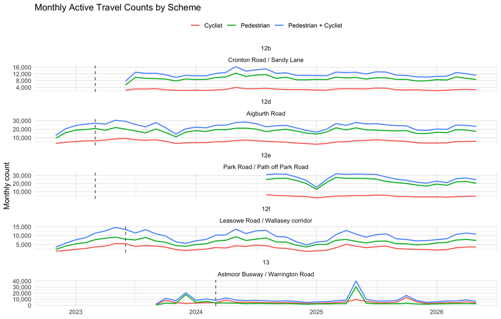

```r
p_scheme <- monthly_scheme |>
  pivot_longer(
    cols = c(pedestrian, cyclist, active_travel_total),
    names_to = "mode",
    values_to = "count"
  ) |>
  mutate(
    mode = recode(
      mode,
      pedestrian = "Pedestrian",
      cyclist = "Cyclist",
      active_travel_total = "Pedestrian + Cyclist"
    )
  ) |>
  ggplot(aes(month_date, count, colour = mode)) +
  geom_line(linewidth = 0.8, na.rm = TRUE) +
  geom_vline(
    aes(xintercept = intervention_date),
    linetype = "dashed",
    colour = "grey35"
  ) +
  facet_wrap(~ scheme_id + road_group, scales = "free_y", ncol = 1) +
  scale_y_continuous(labels = comma) +
  labs(
    title = "Monthly Active Travel Counts by Scheme",
    x = NULL,
    y = "Monthly count",
    colour = NULL
  ) +
  theme_minimal(base_size = 12) +
  theme(legend.position = "top")

p_scheme
```

```r
ggsave(
  filename = file.path(output_dir, "plots", "monthly_scheme_active_travel.png"),
  plot = p_scheme,
  width = 12,
  height = 14,
  dpi = 300
)
```

## 10 Monthly Sensor-Level Trends

The monthly trend plots were repeated at sensor level, faceted by countline. Separating pedestrian and cyclist counts at this stage allows differences in mode response to be identified — for instance, schemes where cyclist counts change more markedly than pedestrian counts, or vice versa. These plots also make it easier to identify individual countlines with anomalous patterns that may affect scheme-level aggregates.

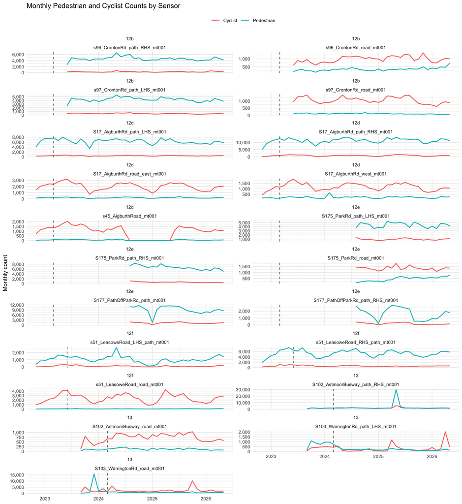

```r
p_sensor <- monthly_sensor |>
  pivot_longer(
    cols = c(pedestrian, cyclist),
    names_to = "mode",
    values_to = "count"
  ) |>
  mutate(
    mode = recode(mode, pedestrian = "Pedestrian", cyclist = "Cyclist")
  ) |>
  ggplot(aes(month_date, count, colour = mode)) +
  geom_line(linewidth = 0.7, na.rm = TRUE) +
  geom_vline(
    aes(xintercept = intervention_date),
    linetype = "dashed",
    colour = "grey35"
  ) +
  facet_wrap(~ scheme_id + countline_name, scales = "free_y", ncol = 2) +
  scale_y_continuous(labels = comma) +
  labs(
    title = "Monthly Pedestrian and Cyclist Counts by Sensor",
    x = NULL,
    y = "Monthly count",
    colour = NULL
  ) +
  theme_minimal(base_size = 10) +
  theme(legend.position = "top")

p_sensor
```

```r
ggsave(
  filename = file.path(output_dir, "plots", "monthly_sensor_pedestrian_cyclist.png"),
  plot = p_sensor,
  width = 14,
  height = 16,
  dpi = 300
)
```

## 11 Weekly Trends

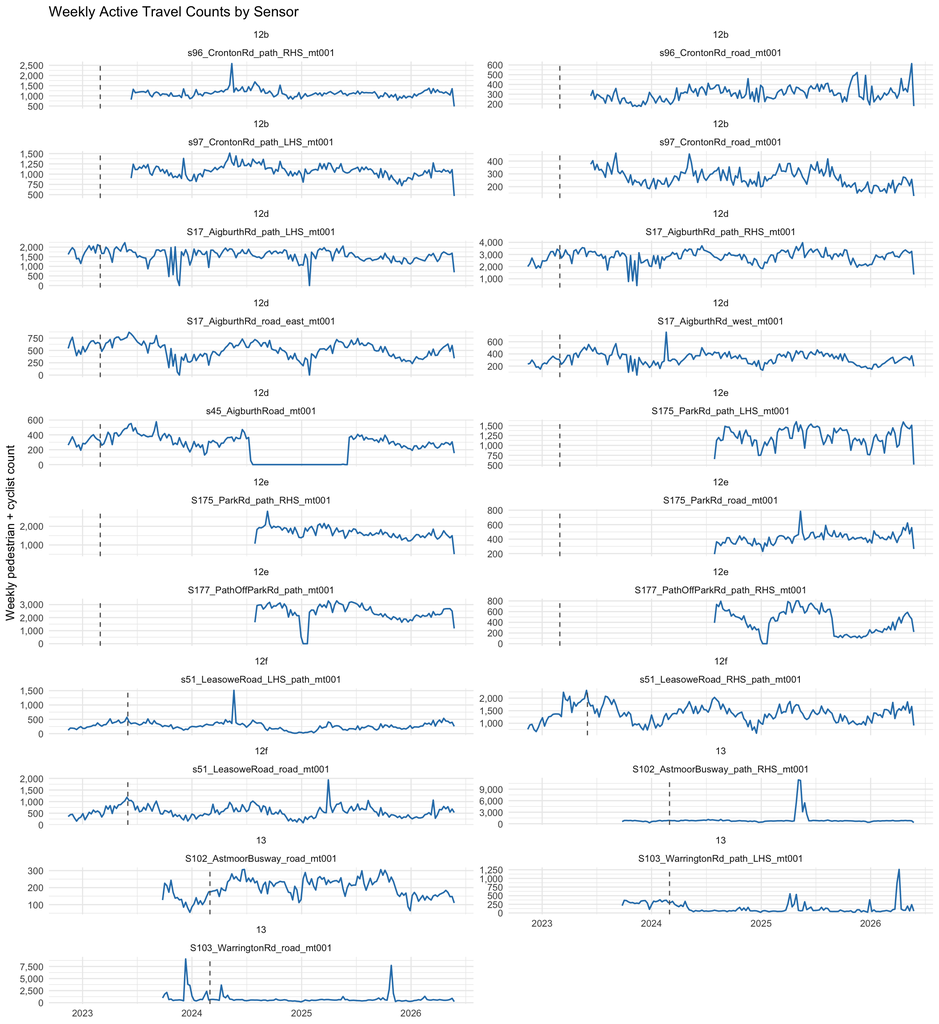

```r
p_weekly <- weekly_sensor |>
  ggplot(aes(week_date, active_travel_total)) +
  geom_line(colour = "#2C7FB8", linewidth = 0.6, na.rm = TRUE) +
  geom_vline(
    aes(xintercept = intervention_date),
    linetype = "dashed",
    colour = "grey35"
  ) +
  facet_wrap(~ scheme_id + countline_name, scales = "free_y", ncol = 2) +
  scale_y_continuous(labels = comma) +
  labs(
    title = "Weekly Active Travel Counts by Sensor",
    x = NULL,
    y = "Weekly pedestrian + cyclist count"
  ) +
  theme_minimal(base_size = 10)

p_weekly
```

```r
ggsave(
  filename = file.path(output_dir, "plots", "weekly_sensor_active_travel.png"),
  plot = p_weekly,
  width = 14,
  height = 16,
  dpi = 300
)
```

## 12 Interpretation Notes

The QA summary table should be the reference point for deciding how each sensor is used in the dissertation analysis. Of the 21 countlines, those categorised as potential pre/post are the only ones for which a before/after impact evaluation is methodologically defensible. Those with post-installation data only can contribute to a descriptive account of active travel patterns since the scheme opened, but should not be used to make claims about the effect of the intervention.

For the sensors that do support a pre/post comparison, any observed change in active travel following installation should not be attributed to the scheme without accounting for background trends, seasonal variation, and the reliability profile of the sensor itself. Where a comparable control site is available, it should be incorporated before drawing conclusions about scheme impact.